# User Guidance for treemaster Package

Zeyu Chen, Linchen Deng, Tingyi Li, Yanning Wu, Yue Yu

12/10/2019

```r
# Library our treemaster package
library(treemaster)
```

# Data Cleansing

In this section, we will show you how to use the data cleansing function in our package for further analysis.

### 1. outlier_delete()

The first function for data leansing is to delete all the outliers in continuous explanatory variables of the input dataset. While using, you need to clarify the indices from what variables are you willing to delete outliers. Let’s take the **BostonHousing** dataset for example.

```r
data <- BostonHousing
str(data)
```

```
#> 'data.frame':    506 obs. of  14 variables:
#>  $ crim   : num  0.00632 0.02731 0.02729 0.03237 0.06905 ...
#>  $ zn     : num  18 0 0 0 0 0 12.5 12.5 12.5 12.5 ...
#>  $ indus  : num  2.31 7.07 7.07 2.18 2.18 2.18 7.87 7.87 7.87 7.87 ...
#>  $ chas   : Factor w/ 2 levels "0","1": 1 1 1 1 1 1 1 1 1 1 ...
#>  $ nox    : num  0.538 0.469 0.469 0.458 0.458 0.458 0.524 0.524 0.524 0.524 ...
#>  $ rm     : num  6.58 6.42 7.18 7 7.15 ...
#>  $ age    : num  65.2 78.9 61.1 45.8 54.2 58.7 66.6 96.1 100 85.9 ...
#>  $ dis    : num  4.09 4.97 4.97 6.06 6.06 ...
#>  $ rad    : num  1 2 2 3 3 3 5 5 5 5 ...
#>  $ tax    : num  296 242 242 222 222 222 311 311 311 311 ...
#>  $ ptratio: num  15.3 17.8 17.8 18.7 18.7 18.7 15.2 15.2 15.2 15.2 ...
#>  $ b      : num  397 397 393 395 397 ...
#>  $ lstat  : num  4.98 9.14 4.03 2.94 5.33 ...
#>  $ medv   : num  24 21.6 34.7 33.4 36.2 28.7 22.9 27.1 16.5 18.9 ...
```

The `medv` column (column 14) is the response column, and as you can see, `crim`, `zn`, `indus`, `nox`, `rm`, `age`, `dis`,`tax`,`pratio`,`b` and `lstat` are continuous explanatory variables (column 1, 2, 3, 5, 6, 7, 8, 10, 11, 12, 13). Categorical explanatory variables are `chas` and `rad` (column 4 and 9).

```r
summary(data)
```

```
#>       crim                zn             indus       chas
#>  Min.   : 0.00632   Min.   :  0.00   Min.   : 0.46   0:471
#>  1st Qu.: 0.08204   1st Qu.:  0.00   1st Qu.: 5.19   1: 35
#>  Median : 0.25651   Median :  0.00   Median : 9.69
#>  Mean   : 3.61352   Mean   : 11.36   Mean   :11.14
#>  3rd Qu.: 3.67708   3rd Qu.: 12.50   3rd Qu.:18.10
#>  Max.   :88.97620   Max.   :100.00   Max.   :27.74
#>       nox               rm             age              dis
#>  Min.   :0.3850   Min.   :3.561   Min.   :  2.90   Min.   : 1.130
#>  1st Qu.:0.4490   1st Qu.:5.886   1st Qu.: 45.02   1st Qu.: 2.100
#>  Median :0.5380   Median :6.208   Median : 77.50   Median : 3.207
#>  Mean   :0.5547   Mean   :6.285   Mean   : 68.57   Mean   : 3.795
#>  3rd Qu.:0.6240   3rd Qu.:6.623   3rd Qu.: 94.08   3rd Qu.: 5.188
#>  Max.   :0.8710   Max.   :8.780   Max.   :100.00   Max.   :12.127
#>       rad              tax           ptratio            b
#>  Min.   : 1.000   Min.   :187.0   Min.   :12.60   Min.   :  0.32
#>  1st Qu.: 4.000   1st Qu.:279.0   1st Qu.:17.40   1st Qu.:375.38
#>  Median : 5.000   Median :330.0   Median :19.05   Median :391.44
#>  Mean   : 9.549   Mean   :408.2   Mean   :18.46   Mean   :356.67
#>  3rd Qu.:24.000   3rd Qu.:666.0   3rd Qu.:20.20   3rd Qu.:396.23
#>  Max.   :24.000   Max.   :711.0   Max.   :22.00   Max.   :396.90
#>      lstat            medv
#>  Min.   : 1.73   Min.   : 5.00
#>  1st Qu.: 6.95   1st Qu.:17.02
#>  Median :11.36   Median :21.20
#>  Mean   :12.65   Mean   :22.53
#>  3rd Qu.:16.95   3rd Qu.:25.00
#>  Max.   :37.97   Max.   :50.00
```

There are no NAs in the original data. The function is supposed to replace the outliers in explanatory continuous data to NAs. After applying the function, the data would look like this.

```r
data <- outlier_delete(data,index = c(1,2,3,5,6,7,8,9,11,12,13))
summary(data)
```

```
#>       crim               zn             indus       chas
#>  Min.   :0.00632   Min.   : 0.000   Min.   : 0.46   0:471
#>  1st Qu.:0.06896   1st Qu.: 0.000   1st Qu.: 5.19   1: 35
#>  Median :0.17644   Median : 0.000   Median : 9.69
#>  Mean   :1.19834   Mean   : 3.193   Mean   :11.14
#>  3rd Qu.:0.96087   3rd Qu.: 0.000   3rd Qu.:18.10
#>  Max.   :8.98296   Max.   :30.000   Max.   :27.74
#>  NA's   :66        NA's   :68
#>       nox               rm             age              dis
#>  Min.   :0.3850   Min.   :4.880   Min.   :  2.90   Min.   :1.130
#>  1st Qu.:0.4490   1st Qu.:5.886   1st Qu.: 45.02   1st Qu.:2.088
#>  Median :0.5380   Median :6.184   Median : 77.50   Median :3.152
#>  Mean   :0.5547   Mean   :6.233   Mean   : 68.57   Mean   :3.724
#>  3rd Qu.:0.6240   3rd Qu.:6.553   3rd Qu.: 94.08   3rd Qu.:5.117
#>  Max.   :0.8710   Max.   :7.691   Max.   :100.00   Max.   :9.223
#>                   NA's   :30                       NA's   :5
#>       rad              tax           ptratio            b
#>  Min.   : 1.000   Min.   :187.0   Min.   :13.60   Min.   :344.9
#>  1st Qu.: 4.000   1st Qu.:279.0   1st Qu.:17.40   1st Qu.:385.9
#>  Median : 5.000   Median :330.0   Median :19.10   Median :393.2
#>  Mean   : 9.549   Mean   :408.2   Mean   :18.62   Mean   :388.7
#>  3rd Qu.:24.000   3rd Qu.:666.0   3rd Qu.:20.20   3rd Qu.:396.9
#>  Max.   :24.000   Max.   :711.0   Max.   :22.00   Max.   :396.9
#>                                   NA's   :15      NA's   :77
#>      lstat            medv
#>  Min.   : 1.73   Min.   : 5.00
#>  1st Qu.: 6.91   1st Qu.:17.02
#>  Median :11.25   Median :21.20
#>  Mean   :12.34   Mean   :22.53
#>  3rd Qu.:16.55   3rd Qu.:25.00
#>  Max.   :30.81   Max.   :50.00
#>  NA's   :7
```

As you can see, the outliers have been replaced by NAs. Now column 1, 2, 6, 8, 11, 12, 13 have NA values inside them, and no outliers in the dataset.

### 2. missing_imputation()

After deleting outliers, there are NAs left in out dataset, and the NAs may mess up the following decision tree and random forest analysis. The missing_imputation function is here to help you replace the NAs with median or mean, and it can work on both categorical variable and continuous variable. While using this function you need to clarify the `index`, `type` and `method` arguemnt. `Type` should be an vector with same length as `index`, and `method` should be whether “mean” or “median”. Let’s try it on the dataset whose outliers have just been deleted. I’m changing NA into the mean of that column.

```r
data <- missing_imputation(data, index = c(1, 2, 6, 8, 11, 12, 13),
                           type = rep("continuous", 7), method = "mean")
summary(data)
```

```
#>       crim               zn             indus       chas
#>  Min.   :0.00632   Min.   : 0.000   Min.   : 0.46   0:471
#>  1st Qu.:0.08205   1st Qu.: 0.000   1st Qu.: 5.19   1: 35
#>  Median :0.25651   Median : 0.000   Median : 9.69
#>  Mean   :1.19834   Mean   : 3.193   Mean   :11.14
#>  3rd Qu.:1.19834   3rd Qu.: 3.193   3rd Qu.:18.10
#>  Max.   :8.98296   Max.   :30.000   Max.   :27.74
#>       nox               rm             age              dis
#>  Min.   :0.3850   Min.   :4.880   Min.   :  2.90   Min.   :1.130
#>  1st Qu.:0.4490   1st Qu.:5.900   1st Qu.: 45.02   1st Qu.:2.100
#>  Median :0.5380   Median :6.224   Median : 77.50   Median :3.207
#>  Mean   :0.5547   Mean   :6.233   Mean   : 68.57   Mean   :3.724
#>  3rd Qu.:0.6240   3rd Qu.:6.515   3rd Qu.: 94.08   3rd Qu.:5.113
#>  Max.   :0.8710   Max.   :7.691   Max.   :100.00   Max.   :9.223
#>       rad              tax           ptratio            b
#>  Min.   : 1.000   Min.   :187.0   Min.   :13.60   Min.   :344.9
#>  1st Qu.: 4.000   1st Qu.:279.0   1st Qu.:17.40   1st Qu.:388.1
#>  Median : 5.000   Median :330.0   Median :19.05   Median :391.4
#>  Mean   : 9.549   Mean   :408.2   Mean   :18.62   Mean   :388.7
#>  3rd Qu.:24.000   3rd Qu.:666.0   3rd Qu.:20.20   3rd Qu.:396.2
#>  Max.   :24.000   Max.   :711.0   Max.   :22.00   Max.   :396.9
#>      lstat            medv
#>  Min.   : 1.73   Min.   : 5.00
#>  1st Qu.: 6.95   1st Qu.:17.02
#>  Median :11.36   Median :21.20
#>  Mean   :12.34   Mean   :22.53
#>  3rd Qu.:16.46   3rd Qu.:25.00
#>  Max.   :30.81   Max.   :50.00
```

As you can see, there is no longer NA in the data now. The outliers in the original data have been successfully replaced by mean value of the variable they belong to.

### 3. create_dummy()

After dealing with the continuous variables, you can move your attention towards categorical variables. The following classification analysis are for binary data only, so you need to get dummy variables for categorical data. While using this function, you will need to clarify the arguments `index`, `remove_first` and `remove_orginal` to control the result data.

```r
data <- create_dummy(data, index = 9, remove_first = TRUE, remove_original = TRUE)
head(data)
```

```
#>      crim zn indus chas   nox    rm  age    dis tax ptratio      b lstat
#> 1 0.00632 18  2.31    0 0.538 6.575 65.2 4.0900 296    15.3 396.90  4.98
#> 2 0.02731  0  7.07    0 0.469 6.421 78.9 4.9671 242    17.8 396.90  9.14
#> 3 0.02729  0  7.07    0 0.469 7.185 61.1 4.9671 242    17.8 392.83  4.03
#> 4 0.03237  0  2.18    0 0.458 6.998 45.8 6.0622 222    18.7 394.63  2.94
#> 5 0.06905  0  2.18    0 0.458 7.147 54.2 6.0622 222    18.7 396.90  5.33
#> 6 0.02985  0  2.18    0 0.458 6.430 58.7 6.0622 222    18.7 394.12  5.21
#>   medv rad_2 rad_3 rad_4 rad_5 rad_6 rad_7 rad_8 rad_24
#> 1 24.0     0     0     0     0     0     0     0      0
#> 2 21.6     1     0     0     0     0     0     0      0
#> 3 34.7     1     0     0     0     0     0     0      0
#> 4 33.4     0     1     0     0     0     0     0      0
#> 5 36.2     0     1     0     0     0     0     0      0
#> 6 28.7     0     1     0     0     0     0     0      0
```

The resulting data has dummy variables created for each value of ‘rad’. Responding to the arguments ‘remove_first = TRUE’ and ‘remove_original = TRUE’, the original ‘rad’ column has been deleted, and 8 dummy varaibles are generating according to the 9 levels of rad.

### 4. standardize_x()

This function aims to standardize all the continuous explanatory variables, for easier comparison and and internal consistency. Remember to state the `index` argument with all column indecies of continuous predictors you want to standardize.

```r
data <- standardize_x(data,index = c(1,2,3,5,6,7,8,9,10,11,12))
data.mean <- c()
data.sd <- c()
#Calculate mean and variance for continuous explanatory variables.
for (i in c(1,2,3,5,6,7,8,9,10,11,12)){
  data.mean[i] <- round(mean(data[,i]),4)
  data.sd[i] <- sd(data[,i])
}
data.mean[c(1,2,3,5,6,7,8,9,10,11,12)]
```

```
#>  [1] 0 0 0 0 0 0 0 0 0 0 0
```

```r
data.sd[c(1,2,3,5,6,7,8,9,10,11,12)]
```

```
#>  [1] 1 1 1 1 1 1 1 1 1 1 1
```

Through the result you have successfully standardized all the continuous explanatory variables, and right now all of them have mean value 0 and standard deviation value 1!

### 5. center_y()

For better interpret the intercept, it is recommended to center the response variable. You need to deal with the response variable here since the response variable in this dataset is also continuous. Remember to specify the `index` where response variable locates

```r
round(mean(data$medv),4)
```

```
#> [1] 22.5328
```

```r
data <- center_y(data, 13)
round(mean(data$medv),4)
```

```
#> [1] 0
```

After centering, the mean of response variable now is 0.

### 6. pca_mca()

When there are too many variables in our dataset, one effective way to reduce dimensionality of the dataset is to use PCA and MCA functions. In this function, for the continuous variables, PCA analysis will be applied and reduce the dimensionality of the original dataset. For the categorical variables, MCA analysis will be applied and reduce the dimensionality of the original dataset. `variance_percent` argument allows you to customize the proportion of dimensions you want to keep.

Make sure you only enter the data with all the predictors you want to reduce dimension from. For the predictors you’d like to keep and the response variable, please do not use the pca_mca() function on them. The indices argument you enter should be indecies in the dataset you are operating pca_mca() on.

```r
head(data)
```

```
#>         crim         zn      indus chas        nox        rm        age
#> 1 -0.6007527  2.0351084 -1.2866362    0 -0.1440749 0.6604772 -0.1198948
#> 2 -0.5901742 -0.4388404 -0.5927944    0 -0.7395304 0.3628847  0.3668034
#> 3 -0.5901843 -0.4388404 -0.5927944    0 -0.7395304 1.8392526 -0.2655490
#> 4 -0.5876241 -0.4388404 -1.3055857    0 -0.8344581 1.4778903 -0.8090878
#> 5 -0.5691382 -0.4388404 -1.3055857    0 -0.8344581 1.7658207 -0.5106743
#> 6 -0.5888941 -0.4388404 -1.3055857    0 -0.8344581 0.3802765 -0.3508100
#>         dis        tax     ptratio         b     lstat       medv rad_2
#> 1 0.1850219 -0.6659492 -1.71723678 0.7960790 -1.109989  1.4671937     0
#> 2 0.6280526 -0.9863534 -0.42594289 0.7960790 -0.482652 -0.9328063     1
#> 3 0.6280526 -0.9863534 -0.42594289 0.4006766 -1.253252 12.1671937     1
#> 4 1.1811970 -1.1050216  0.03892291 0.5755475 -1.417626 10.8671937     0
#> 5 1.1811970 -1.1050216  0.03892291 0.7960790 -1.057209 13.6671937     0
#> 6 1.1811970 -1.1050216  0.03892291 0.5260007 -1.075305  6.1671937     0
#>   rad_3 rad_4 rad_5 rad_6 rad_7 rad_8 rad_24
#> 1     0     0     0     0     0     0      0
#> 2     0     0     0     0     0     0      0
#> 3     0     0     0     0     0     0      0
#> 4     1     0     0     0     0     0      0
#> 5     1     0     0     0     0     0      0
#> 6     1     0     0     0     0     0      0
```

```r
#Split the data we want to do PCA/MCA analysis from the data we want to keep.
data.pca_mca <- data[,c(1,2,3,5,6,7,8,9,10,11,12)]
medv <- data[,13]
chas <- data[,4]
data_dummy <- data[,c(14,15,16,17,18,19,20,21)]
data.pca_mca <- pca_mca(data.pca_mca, variance_percent = 0.9,
                        cont_col_id = c(1,2,3,4,5,6,7,8,9,10,11))
#Bind the after PCA/MCA part and the kept original part together.
data <- cbind(data.pca_mca, chas, data_dummy, medv)
head(data)
```

```
#>   PCA_Dim_1  PCA_Dim_2   PCA_Dim_3  PCA_Dim_4   PCA_Dim_5  PCA_Dim_6
#> 1 -2.397002  0.3321492 -0.02405602 -0.4841018  2.23785526  0.2577299
#> 2 -1.419845 -0.5040799  0.32424675 -0.9678179 -0.09466865 -0.1378153
#> 3 -2.151346  0.9122993  0.77912994 -1.1883898 -0.27753209 -0.4914709
#> 4 -2.800041  0.5305794  1.02633780 -0.6573494 -0.74430394 -0.2944115
#> 5 -2.643804  0.4592017  1.24158232 -0.7898380 -0.52046849 -0.4166120
#> 6 -2.310624 -0.2696975  0.48267550 -0.4231088 -0.72336082 -0.1368835
#>     PCA_Dim_7 chas rad_2 rad_3 rad_4 rad_5 rad_6 rad_7 rad_8 rad_24
#> 1 -0.44390836    0     0     0     0     0     0     0     0      0
#> 2  0.06217119    0     1     0     0     0     0     0     0      0
#> 3  0.24348488    0     1     0     0     0     0     0     0      0
#> 4  0.04543588    0     0     1     0     0     0     0     0      0
#> 5  0.39528280    0     0     1     0     0     0     0     0      0
#> 6 -0.23684599    0     0     1     0     0     0     0     0      0
#>         medv
#> 1  1.4671937
#> 2 -0.9328063
#> 3 12.1671937
#> 4 10.8671937
#> 5 13.6671937
#> 6  6.1671937
```

By using this function, you have successfully reduced total amount of variable from 21 to 17, and amout of continuous variable from 11 to 7.

After cleansing your data, you can set your foot on the next step: tree analysis!

# Random Forest Model

In this section, we will show how to use the random forest model contained in our pakcage.

## Binary Classification Problem

The first type of real-world problem that our package can be used to deal with is the binary classification problem. Let’s consider the **PimaIndiansDiabetes** dataset provided by our package.

```r
# Get the PimaIndiansDiabetes dataset
data("PimaIndiansDiabetes")
class_data <- PimaIndiansDiabetes
# Display the structure of the dataset
str(class_data)
```

```
#> 'data.frame':    768 obs. of  9 variables:
#>  $ pregnant: num  6 1 8 1 0 5 3 10 2 8 ...
#>  $ glucose : num  148 85 183 89 137 116 78 115 197 125 ...
#>  $ pressure: num  72 66 64 66 40 74 50 0 70 96 ...
#>  $ triceps : num  35 29 0 23 35 0 32 0 45 0 ...
#>  $ insulin : num  0 0 0 94 168 0 88 0 543 0 ...
#>  $ mass    : num  33.6 26.6 23.3 28.1 43.1 25.6 31 35.3 30.5 0 ...
#>  $ pedigree: num  0.627 0.351 0.672 0.167 2.288 ...
#>  $ age     : num  50 31 32 21 33 30 26 29 53 54 ...
#>  $ diabetes: Factor w/ 2 levels "neg","pos": 2 1 2 1 2 1 2 1 2 2 ...
```

```r
# Display the summary of the dataset
summary(class_data)
```

```
#>     pregnant         glucose         pressure         triceps
#>  Min.   : 0.000   Min.   :  0.0   Min.   :  0.00   Min.   : 0.00
#>  1st Qu.: 1.000   1st Qu.: 99.0   1st Qu.: 62.00   1st Qu.: 0.00
#>  Median : 3.000   Median :117.0   Median : 72.00   Median :23.00
#>  Mean   : 3.845   Mean   :120.9   Mean   : 69.11   Mean   :20.54
#>  3rd Qu.: 6.000   3rd Qu.:140.2   3rd Qu.: 80.00   3rd Qu.:32.00
#>  Max.   :17.000   Max.   :199.0   Max.   :122.00   Max.   :99.00
#>     insulin           mass          pedigree           age
#>  Min.   :  0.0   Min.   : 0.00   Min.   :0.0780   Min.   :21.00
#>  1st Qu.:  0.0   1st Qu.:27.30   1st Qu.:0.2437   1st Qu.:24.00
#>  Median : 30.5   Median :32.00   Median :0.3725   Median :29.00
#>  Mean   : 79.8   Mean   :31.99   Mean   :0.4719   Mean   :33.24
#>  3rd Qu.:127.2   3rd Qu.:36.60   3rd Qu.:0.6262   3rd Qu.:41.00
#>  Max.   :846.0   Max.   :67.10   Max.   :2.4200   Max.   :81.00
#>  diabetes
#>  neg:500
#>  pos:268
#>
#>
#>
#>
```

```r
# Display the head of the dataset
head(class_data)
```

```
#>   pregnant glucose pressure triceps insulin mass pedigree age diabetes
#> 1        6     148       72      35       0 33.6    0.627  50      pos
#> 2        1      85       66      29       0 26.6    0.351  31      neg
#> 3        8     183       64       0       0 23.3    0.672  32      pos
#> 4        1      89       66      23      94 28.1    0.167  21      neg
#> 5        0     137       40      35     168 43.1    2.288  33      pos
#> 6        5     116       74       0       0 25.6    0.201  30      neg
```

As shown by the data structure and data summary above, there are 8 continuous predictors (`pregnant`, `glucose`, `pressure`, `triceps`, `insulin`, `mass`, `pedigree` and `age`) and 1 binary response (`diabetes`) in this dataset. For more information about the meaning of each variable, you can use **?PimaIndiansDiabetes** to take a look at our help file for this dataset.  
Note that, the response variable `diabetes` is in the 9th column of the dataset. The first row’s observation has positive response in this problem. Let’s then fit a random forest model on this dataset.

### 1. randomfroest_build()

A random forest model can be fitted using the **randomforest_build()** function provided by our package. For details about the arguments in this function, you can take a look at our help file by **?randomforest_build**. Here, I just want to mention that our function allows two types of measurements to measure the variable importance in a random forest model, `accuracy` and `impurity`. For simplicity, we will use the accuracy measurement in this example, the impurity measurement will be used in the later section. It’s time to fit the model.

```r
# Fit the random forest model, m=0.8 means that 80% of the observations will be used as train set.
# positive_class=1 because the first row's observation has positive class response.
class_mod <- randomforest_build(data = class_data, m = 0.8, index = 9,
                                indicator = "classification", num_trees = 150,
                                num_variables_split = 3, replace = TRUE, node_size = 1,
                                importance_measure = "accuracy", positive_class = 1)
```

For a binary classification problem, the return value of this function is a list containing seven objects (`VarImportancePlot`, `ROCPlot`, `KSPlot`, `ConfusionMatrix`, `Accuracy`, `rocit_object`, `RFmodel`), we will encounter them one by one in the following sections.

### 2. var_imp_plot()

The object `VarImportancePlot` returned by the **randomforest_build()** function is actually a ggplot object describing the variable importance in the fitted random forest model, we can take a look at it.

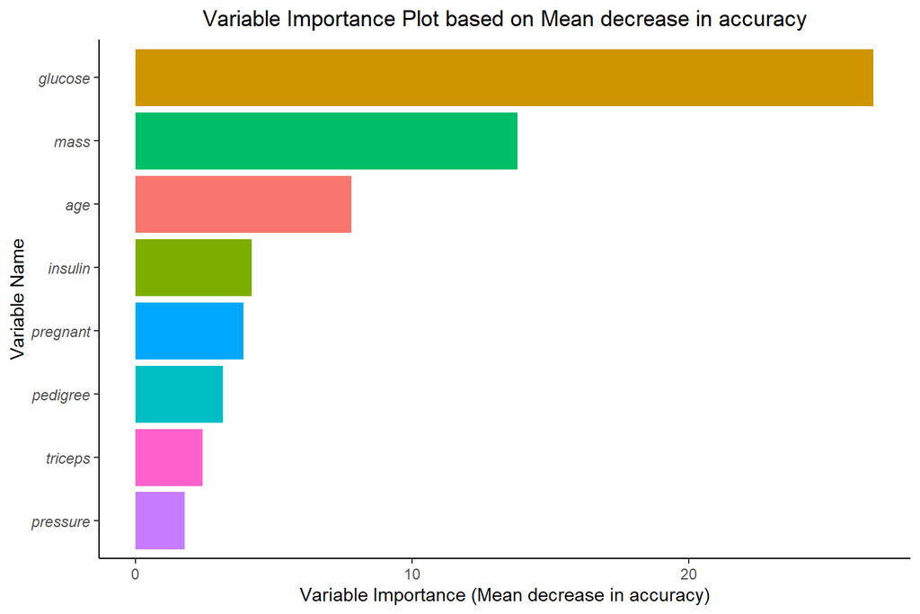

```r
class_mod$VarImportancePlot
```

We also provide the function **var_imp_plot()** which allows you to generate the variable importance plot by yourself. For details about the arguments in this function, you can take a look at our help file by **?var_imp_plot**. In order to use this function correctly, we need to provide the fitted random forest model object, which is just like the object `RFmodel` returned by **randomforest_build()** function. That’s why we also let the **randomforest_build()** function return the `RFmodel` object.

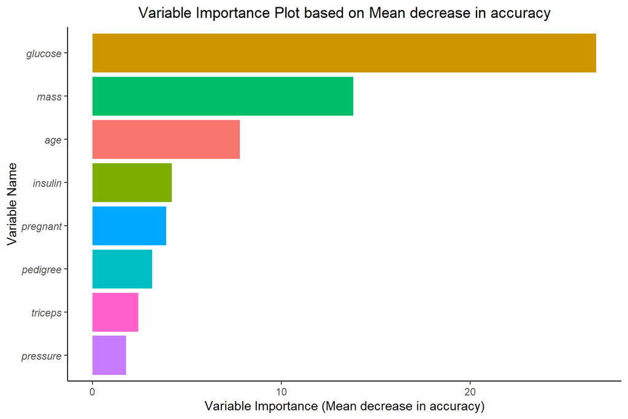

```r
# Generate the variable importance plot again
# measure_type=1 because we are using the accuracy importance measure
# name is the detailed measurement name that will be displayed in the plot title
var_imp_plot(model = class_mod$RFmodel, measure_type = 1, name = "Mean decrease in accuracy")
```

As you can see, these two plots are exactly the same. Actually, we don’t provide this function just for you to generate a duplicate plot, the **var_imp_plot()** function can be used to generate the variance importance plot of a random forest model in more general cases as long as you can provide a fitted random forest model object (ususally the returned value of the **randomForest()** function).

### 3. roc_plot()

The object `ROCPlot` returned by the **randomforest_build()** function is actually a ggplot object describing the ROC Curve and AUC Score of the fitted random forest binary classifcation model’s performance on the test dataset, we can take a look at it.

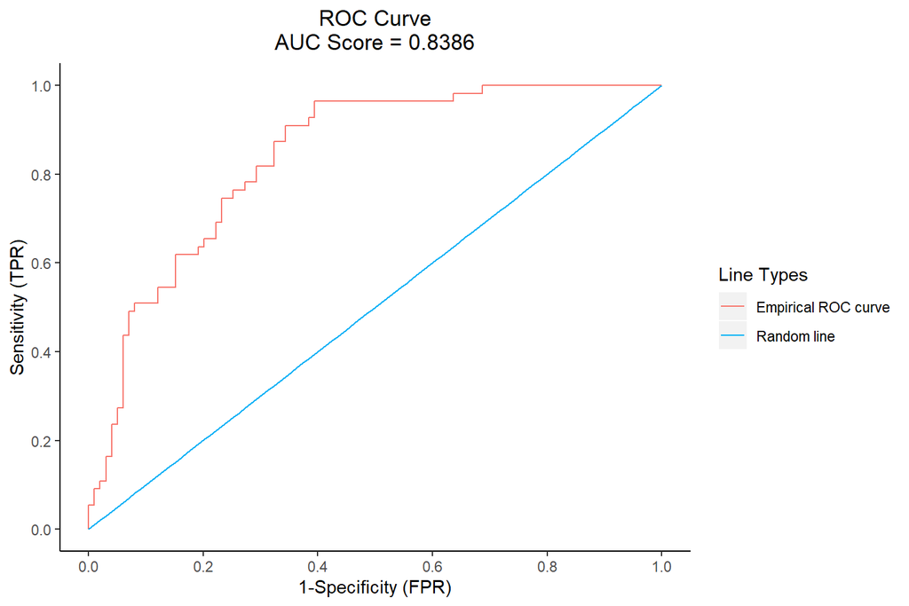

```r
class_mod$ROCPlot
```

We also provide the function **roc_plot()** which allows you to generate the ROC Curve and AUC Score plot by yourself. For details about the arguments in this function, you can take a look at our help file by **?roc_plot**. In order to use this function correctly, we need to provide an object returned by the **rocit()** function in the `ROCit` package, which is just like the object `rocit_object` returned by **randomforest_build()** function. That’s why we also let the **randomforest_build()** function return the `rocit_object` object.

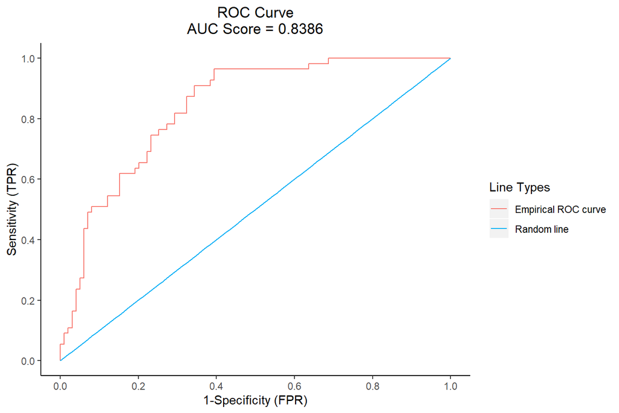

```r
# Generate the ROC Curve and AUC Score plot again
# roc is an object returned by the rocit() function in the ROCit package,
roc_plot(roc = class_mod$rocit_object)
```

As you can see, these two plots are exactly the same. Actually, we don’t provide this function just for you to generate a duplicate plot, the **roc_plot()** function can be used to generate the ROC Curve and AUC Score plot of a binary classification model in more general cases as long as you can provide an object returned by the **rocit()** function in the `ROCit` package.

### 4. ks_plot()

The object `KSPlot` returned by the **randomforest_build()** function is actually a ggplot object describing the K-S Curve and K-S Statistic of the fitted random forest binary classifcation model’s performance on the test dataset, we can take a look at it.

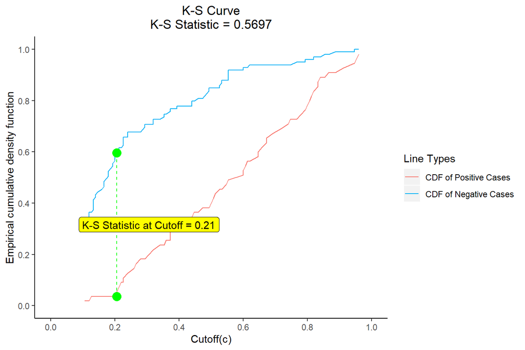

```r
class_mod$KSPlot
```

We also provide the function **ks_plot()** which allows you to generate the K-S Curve and K-S Statistic plot by yourself. For details about the arguments in this function, you can take a look at our help file by **?ks_plot**. In order to use this function correctly, we also need to provide an object returned by the **rocit()** function in the `ROCit` package, which is just like the object `rocit_object` returned by **randomforest_build()** function. That’s why we also let the **randomforest_build()** function return the `rocit_object` object.

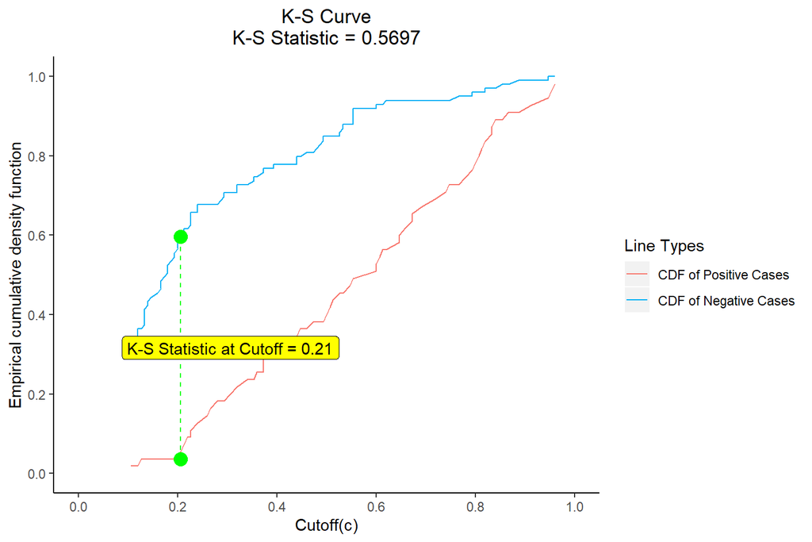

```r
# Generate the K-S Curve and K-S Statistic plot again
# roc is an object returned by the rocit() function in the ROCit package,
ks_plot(roc = class_mod$rocit_object)
```

As you can see, these two plots are exactly the same. Actually, we don’t provide this function just for you to generate a duplicate plot, the **ks_plot()** function can be used to generate the K-S Curve and K-S Statistic plot of a binary classification model in more general cases as long as you can provide an object returned by the **rocit()** function in the `ROCit` package.

### 5. confusion_matrix_plot()

Confusion matrix is an important technique to evaluate the performance of a binary classification model. The **confusion_matrix_plot()** function provided by our package offers you a convenient way to generate a fancy confusion matrix plot of your binary classification model. For details about the arguments in this function, you can take a look at our help file by **?confusion_matrix_plot**. In order to use this function correctly, we need to provide an object returned by the **confusionMatrix()** function in the `caret` package, which is just like the object `ConfusionMatrix` returned by **randomforest_build()** function. That’s why we also let the **randomforest_build()** function return the `ConfusionMatrix` object.

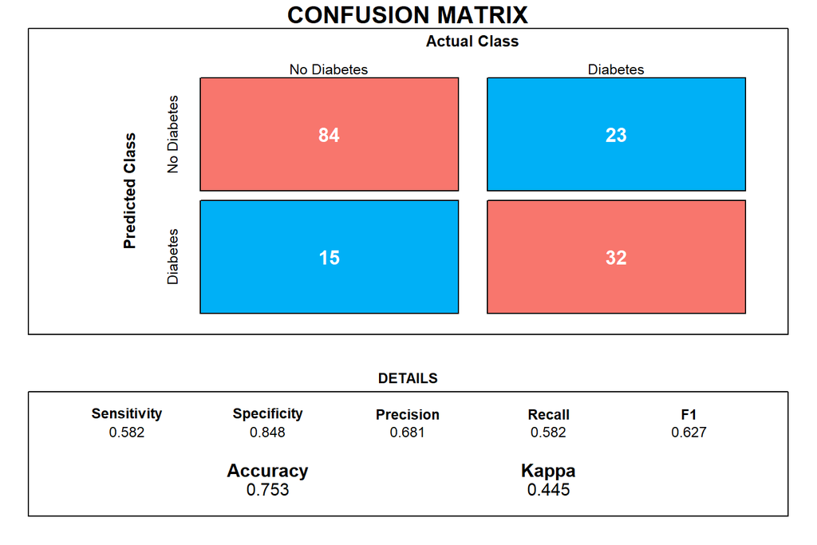

```r
# Generate the Confusion Matrix plot
# positive and negative are the positive and negative class names that will be displayed in the plot
confusion_matrix_plot(cm_matrix = class_mod$ConfusionMatrix, positive = "Diabetes",
                      negative = "No Diabetes")
```

This **confusion_matrix_plot()** function can be used to generate the fancy confusion matrix plot of a binary classification model in more general cases as long as you can provide an object returned by the **confusionMatrix()** function in the `caret` package.

### 6. num_trees_tune()

An important parameter in a random forest model is the number of trees, which can to a great extent affect the model performance. Therefore, our package provides you with a convenient function **num_trees_tune()** to help you find the optimal number of trees in the random forest model for your problem. Here, I just want to mention that this function is developed based on the previous **randomforest_build()** function, therefore, all the arguments in this function are the same as **randomforest_build()** function’s arguments except for the `num_trees` argument, we provide two additional arguments `max_trees` and `min_trees` for this function to determine the search interval for the optimal `num_trees`. For details about the arguments in this function, you can take a look at our help file by **?num_trees_tune**.

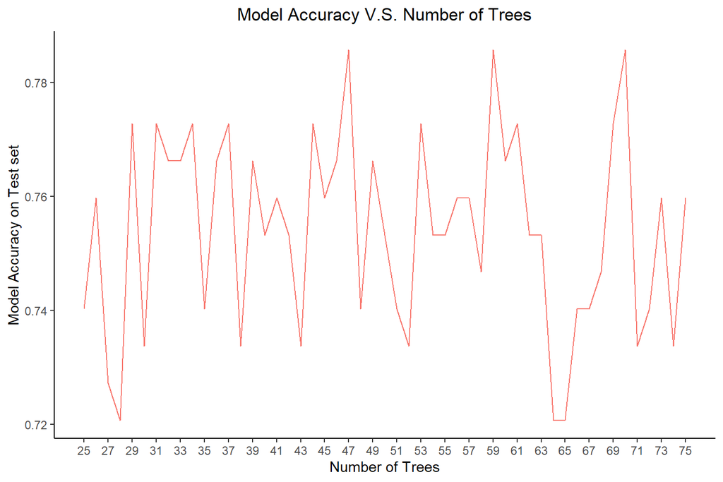

```r
num_trees_tune(data = class_data, m = 0.8, index = 9, indicator = "classification",
               max_trees = 75, min_trees = 25, num_variables_split = 3, replace = TRUE,
               node_size = 1, importance_measure = "accuracy", positive_class = 1)
```

As you can see, for a binary classification problem, this function will generate a plot describing the relationship between model classification accuracy on the test set and number of trees in the model, which will help you to determine the optimal number of trees within your search interval with respect to accuracy. Actually, that’s reason why we let the **randomforest_build()** function return the `Accuracy` value (model classification accuracy on the test set), this value can be used inside the **num_trees_tune()** function to generate the plot above.

## Regression Problem

The second type of real-world problem that our package can be used to deal with is the regression problem. Let’s consider the **BostonHousing** dataset provided by our package.

```r
# Get the Regression dataset
data("BostonHousing")
reg_data <- BostonHousing
# Display the structure of the dataset
str(reg_data)
```

```
#> 'data.frame':    506 obs. of  14 variables:
#>  $ crim   : num  0.00632 0.02731 0.02729 0.03237 0.06905 ...
#>  $ zn     : num  18 0 0 0 0 0 12.5 12.5 12.5 12.5 ...
#>  $ indus  : num  2.31 7.07 7.07 2.18 2.18 2.18 7.87 7.87 7.87 7.87 ...
#>  $ chas   : Factor w/ 2 levels "0","1": 1 1 1 1 1 1 1 1 1 1 ...
#>  $ nox    : num  0.538 0.469 0.469 0.458 0.458 0.458 0.524 0.524 0.524 0.524 ...
#>  $ rm     : num  6.58 6.42 7.18 7 7.15 ...
#>  $ age    : num  65.2 78.9 61.1 45.8 54.2 58.7 66.6 96.1 100 85.9 ...
#>  $ dis    : num  4.09 4.97 4.97 6.06 6.06 ...
#>  $ rad    : num  1 2 2 3 3 3 5 5 5 5 ...
#>  $ tax    : num  296 242 242 222 222 222 311 311 311 311 ...
#>  $ ptratio: num  15.3 17.8 17.8 18.7 18.7 18.7 15.2 15.2 15.2 15.2 ...
#>  $ b      : num  397 397 393 395 397 ...
#>  $ lstat  : num  4.98 9.14 4.03 2.94 5.33 ...
#>  $ medv   : num  24 21.6 34.7 33.4 36.2 28.7 22.9 27.1 16.5 18.9 ...
```

```r
# Display the summary of the dataset
summary(reg_data)
```

```
#>       crim                zn             indus       chas
#>  Min.   : 0.00632   Min.   :  0.00   Min.   : 0.46   0:471
#>  1st Qu.: 0.08204   1st Qu.:  0.00   1st Qu.: 5.19   1: 35
#>  Median : 0.25651   Median :  0.00   Median : 9.69
#>  Mean   : 3.61352   Mean   : 11.36   Mean   :11.14
#>  3rd Qu.: 3.67708   3rd Qu.: 12.50   3rd Qu.:18.10
#>  Max.   :88.97620   Max.   :100.00   Max.   :27.74
#>       nox               rm             age              dis
#>  Min.   :0.3850   Min.   :3.561   Min.   :  2.90   Min.   : 1.130
#>  1st Qu.:0.4490   1st Qu.:5.886   1st Qu.: 45.02   1st Qu.: 2.100
#>  Median :0.5380   Median :6.208   Median : 77.50   Median : 3.207
#>  Mean   :0.5547   Mean   :6.285   Mean   : 68.57   Mean   : 3.795
#>  3rd Qu.:0.6240   3rd Qu.:6.623   3rd Qu.: 94.08   3rd Qu.: 5.188
#>  Max.   :0.8710   Max.   :8.780   Max.   :100.00   Max.   :12.127
#>       rad              tax           ptratio            b
#>  Min.   : 1.000   Min.   :187.0   Min.   :12.60   Min.   :  0.32
#>  1st Qu.: 4.000   1st Qu.:279.0   1st Qu.:17.40   1st Qu.:375.38
#>  Median : 5.000   Median :330.0   Median :19.05   Median :391.44
#>  Mean   : 9.549   Mean   :408.2   Mean   :18.46   Mean   :356.67
#>  3rd Qu.:24.000   3rd Qu.:666.0   3rd Qu.:20.20   3rd Qu.:396.23
#>  Max.   :24.000   Max.   :711.0   Max.   :22.00   Max.   :396.90
#>      lstat            medv
#>  Min.   : 1.73   Min.   : 5.00
#>  1st Qu.: 6.95   1st Qu.:17.02
#>  Median :11.36   Median :21.20
#>  Mean   :12.65   Mean   :22.53
#>  3rd Qu.:16.95   3rd Qu.:25.00
#>  Max.   :37.97   Max.   :50.00
```

```r
# Display the head of the dataset
head(reg_data)
```

```
#>      crim zn indus chas   nox    rm  age    dis rad tax ptratio      b
#> 1 0.00632 18  2.31    0 0.538 6.575 65.2 4.0900   1 296    15.3 396.90
#> 2 0.02731  0  7.07    0 0.469 6.421 78.9 4.9671   2 242    17.8 396.90
#> 3 0.02729  0  7.07    0 0.469 7.185 61.1 4.9671   2 242    17.8 392.83
#> 4 0.03237  0  2.18    0 0.458 6.998 45.8 6.0622   3 222    18.7 394.63
#> 5 0.06905  0  2.18    0 0.458 7.147 54.2 6.0622   3 222    18.7 396.90
#> 6 0.02985  0  2.18    0 0.458 6.430 58.7 6.0622   3 222    18.7 394.12
#>   lstat medv
#> 1  4.98 24.0
#> 2  9.14 21.6
#> 3  4.03 34.7
#> 4  2.94 33.4
#> 5  5.33 36.2
#> 6  5.21 28.7
```

As shown by the data structure and data summary above, there are 12 continuous predictors (`crim`, `zn`, `indus`, `nox`, `rm`, `age`, `dis`, `rad`, `tax`, `ptratio`, `b` and `lastat`), 1 categorical predictor (`chas`) and 1 continuous response (`medv`) in this dataset. For more information about the meaning of each variable, you can use **?BostonHousing** to take a look at our help file for this dataset. Note that, the response variable `medv` is in the 14th column of the dataset. Let’s then fit a random forest model on this dataset.

### 1. randomfroest_build()

Again, we fit a random forest model using the **randomforest_build()** function. Here, we will use the impurity measurement to measure variable importance in the fitted model. It’s time to fit the model.

```r
# Fit the random forest model, m=0.8 means that 80% of the observations will be used as train set.
# indicator="regression" for regression problem.
reg_mod <- randomforest_build(data = reg_data, m = 0.8, index = 14,
                              indicator = "regression", num_trees = 150,
                              num_variables_split = 3, replace = TRUE, node_size = 5,
                              importance_measure = "impurity")
```

For a regression problem, the return value of this function is a list containing three objects (`VarImportancePlot`, `RMSE`, `RFmodel`), we will encounter them one by one in the following sections.

### 2. var_imp_plot()

The same as the case for binary classification problem, the object `VarImportancePlot` returned by the **randomforest_build()** function is still a ggplot object describing the variable importance in the fitted random forest model. We can directly call it or use the function **var_imp_plot()** with the object `RFmodel` returned by **randomforest_build()** function as an input argument, the generated plots should be exactly the same.

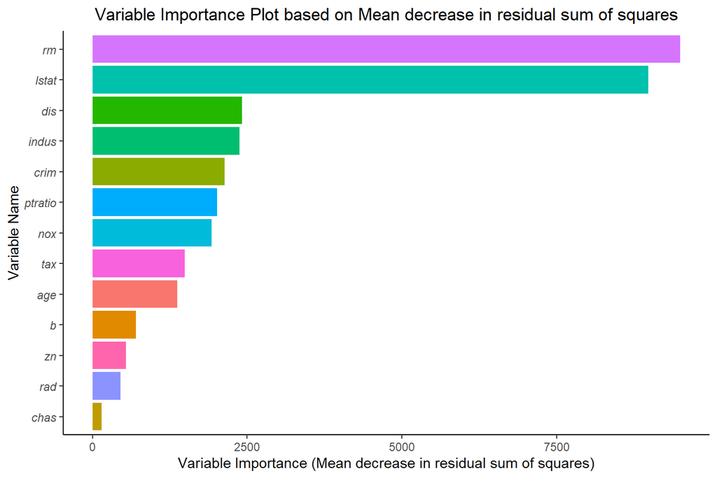

```r
reg_mod$VarImportancePlot
```

Given that I have already discussed about the usage of **var_imp_plot()** function before, so I won’t talk about it again here.

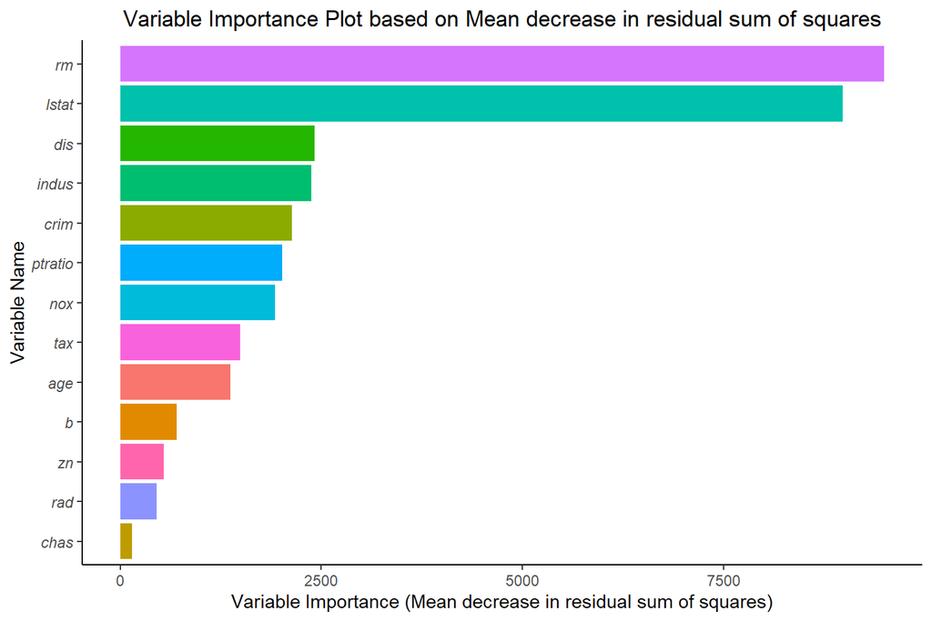

```r
# Generate the variable importance plot again
# measure_type=2 because we are using the impurity importance measure
# name is the detailed measurement name that will be displayed in the plot title
var_imp_plot(model = reg_mod$RFmodel, measure_type = 2,
             name = "Mean decrease in residual sum of squares")
```

### 3. num_trees_tune()

For regression problem, you can also call the **num_trees_tune()** function to generate a plot and help you find the optimal number of trees in the random forest model.

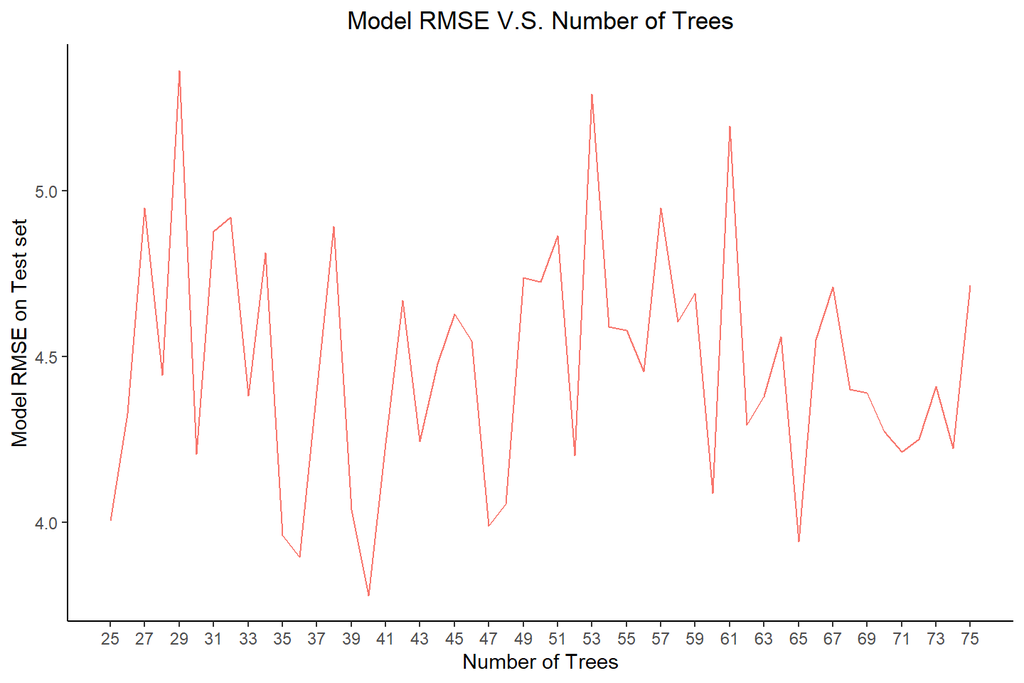

```r
num_trees_tune(data = reg_data, m = 0.8, index = 14, indicator = "regression",
               max_trees = 75, min_trees = 25, num_variables_split = 3, replace = TRUE,
               node_size = 5, importance_measure = "impurity")
```

As you can see, compared to the plot for binary classification problem, the only difference is that the Y-Axis becomes the RMSE on the test set. Actually, that’s reason why we let the **randomforest_build()** function return the `RMSE` value for regression problem, this value can be used inside the **num_trees_tune()** function to generate the plot above. More details of the **num_trees_tune()** function have been discussed before, so I won’t dicuss them again here.

# Decision Tree Model

In this section, we will show how to use the decision tree model contained in our pakcage.

## Binary Classification Problem

The first type of real-world problem that our package can be used to deal with is the binary classification problem. Let’s consider the **PimaIndiansDiabetes** dataset provided by our package.

```r
# Get the PimaIndiansDiabetes dataset
data("PimaIndiansDiabetes")
class_data <- PimaIndiansDiabetes
# Display the structure of the dataset
str(class_data)
```

```
#> 'data.frame':    768 obs. of  9 variables:
#>  $ pregnant: num  6 1 8 1 0 5 3 10 2 8 ...
#>  $ glucose : num  148 85 183 89 137 116 78 115 197 125 ...
#>  $ pressure: num  72 66 64 66 40 74 50 0 70 96 ...
#>  $ triceps : num  35 29 0 23 35 0 32 0 45 0 ...
#>  $ insulin : num  0 0 0 94 168 0 88 0 543 0 ...
#>  $ mass    : num  33.6 26.6 23.3 28.1 43.1 25.6 31 35.3 30.5 0 ...
#>  $ pedigree: num  0.627 0.351 0.672 0.167 2.288 ...
#>  $ age     : num  50 31 32 21 33 30 26 29 53 54 ...
#>  $ diabetes: Factor w/ 2 levels "neg","pos": 2 1 2 1 2 1 2 1 2 2 ...
```

```r
# Display the summary of the dataset
summary(class_data)
```

```
#>     pregnant         glucose         pressure         triceps
#>  Min.   : 0.000   Min.   :  0.0   Min.   :  0.00   Min.   : 0.00
#>  1st Qu.: 1.000   1st Qu.: 99.0   1st Qu.: 62.00   1st Qu.: 0.00
#>  Median : 3.000   Median :117.0   Median : 72.00   Median :23.00
#>  Mean   : 3.845   Mean   :120.9   Mean   : 69.11   Mean   :20.54
#>  3rd Qu.: 6.000   3rd Qu.:140.2   3rd Qu.: 80.00   3rd Qu.:32.00
#>  Max.   :17.000   Max.   :199.0   Max.   :122.00   Max.   :99.00
#>     insulin           mass          pedigree           age
#>  Min.   :  0.0   Min.   : 0.00   Min.   :0.0780   Min.   :21.00
#>  1st Qu.:  0.0   1st Qu.:27.30   1st Qu.:0.2437   1st Qu.:24.00
#>  Median : 30.5   Median :32.00   Median :0.3725   Median :29.00
#>  Mean   : 79.8   Mean   :31.99   Mean   :0.4719   Mean   :33.24
#>  3rd Qu.:127.2   3rd Qu.:36.60   3rd Qu.:0.6262   3rd Qu.:41.00
#>  Max.   :846.0   Max.   :67.10   Max.   :2.4200   Max.   :81.00
#>  diabetes
#>  neg:500
#>  pos:268
#>
#>
#>
#>
```

```r
# Display the head of the dataset
head(class_data)
```

```
#>   pregnant glucose pressure triceps insulin mass pedigree age diabetes
#> 1        6     148       72      35       0 33.6    0.627  50      pos
#> 2        1      85       66      29       0 26.6    0.351  31      neg
#> 3        8     183       64       0       0 23.3    0.672  32      pos
#> 4        1      89       66      23      94 28.1    0.167  21      neg
#> 5        0     137       40      35     168 43.1    2.288  33      pos
#> 6        5     116       74       0       0 25.6    0.201  30      neg
```